# Lab5

Anna Ramji

2023-02-07

This week’s lab is a musical lab. You’ll be requesting data from the Spotify API and using it to build k-nearest neighbor and decision tree models.

In order to use the Spotify API you must have a Spotify account. If you don’t have one, sign up for a free one here: https://www.spotify.com/us/signup

Once you have an account, go to Spotify for developers (https://developer.spotify.com/) and log in. Click the green “Create a Client ID” button to fill out the form to create an app create an app so you can access the API.

On your developer dashboard page, click on the new app you just created. Go to Settings -> Basic Information and you will find your Client ID . Click “View client secret” to access your secondary Client ID. Scroll down to Redirect URIs and enter: http://localhost:1410/

You have two options for completing this lab.

**Option 1**: **Classify by users**. Build models that predict whether a given song will be in your collection vs. a partner in class. This requires that you were already a Spotify user so you have enough data to work with. You will download your data from the Spotify API and then exchange with another member of class.

**Option 2**: **Classify by genres**. Build models that predict which genre a song belongs to. This will use a pre-existing Spotify dataset available from Kaggle.com (https://www.kaggle.com/datasets/mrmorj/dataset-of-songs-in-spotify)

```r
knitr::opts_chunk$set(echo = TRUE, message = FALSE, warning = FALSE)
```

```r
library(spotifyr) #API interaction
library(tidyverse)
library(tidymodels)
library(here)
library(parsnip)
library(caret)
library(rpart.plot) # for decision trees
library(xgboost) #package for boosted trees
library(ranger) #package for random forest
library(patchwork)
library(baguette)
library(vip) #variable importance
library(gt) # for nicer table outputs

set.seed(123)
```

Client ID and Client Secret are required to create and access token that is required to interact with the API. You can set them as system values so we don’t have to do provide them each time.

```r
Sys.setenv(SPOTIFY_CLIENT_ID = 'd501ac8e44a540e491fe8b2125edc43c')

Sys.setenv(SPOTIFY_CLIENT_SECRET = '49f3b563b8de4cb9a2ed0b09741553d6')

authorization_code <- get_spotify_authorization_code(scope = scopes()[c(1:19)]) #sets an authorization code that you'll need to provide for certain get_ functions via my_tracks <- get_my_saved_tracks(authorization = authorization_code)

access_token <- get_spotify_access_token() #takes ID and SECRET, sends to Spotify and receives an access token
```

**Option 1: Data Preparation**

You can use get_my_saved_tracks() to request all your liked tracks. It would be good if you had at least 150-200 liked tracks so the model has enough data to work with. If you don’t have enough liked tracks, you can instead use get_my_recently_played(), and in that case grab at least 500 recently played tracks if you can.

```r
# manually
# my_tracks_1 <- get_my_saved_tracks(authorization = authorization_code,
#                                    limit = 50, offset = 0)
# my_tracks_2 <- get_my_saved_tracks(authorization = authorization_code,
#                                    limit = 50, offset = 50)
# my_tracks_3 <- get_my_saved_tracks(authorization = authorization_code,
#                                    limit = 50, offset = 100)
# my_tracks_4 <- get_my_saved_tracks(authorization = authorization_code,
#                                    limit = 50, offset = 150)
#
# my_tracks <- rbind(my_tracks_1, my_tracks_2, my_tracks_3, my_tracks_4)
```

The Spotify API returns a dataframe of tracks and associated attributes. However, it will only return up to 50 (or 20) tracks at a time, so you will have to make multiple requests. Use a function to combine all your requests in one call.

```r
# creating and using a function

# intialize empty dataframe
all_my_tracks <- data.frame()
# set initial offset (starting point)
offset = 0

# create function to iteratively retrieve tracks data
track_function <- function(tracks) {
  for (i in 1:tracks){
    # for each iteration, get new tracks
    new_tracks <- get_my_saved_tracks(
      # using this authorization code
      authorization = authorization_code,
      # specifying a limit of 50
      limit = 50,
      # set the offset to whatever the offset is at this iteration
      offset = offset)

    # after retrieving that data, add 50 to the offset for the next iteration
    offset = offset + 50

    # and append / save tracks to the initial dataframe
    all_my_tracks <- rbind(all_my_tracks, new_tracks)

  }

  # return the final dataframe with all rows (specified by number of iterations x 50)
  return(all_my_tracks)

}

# retrieving information on 4 x 50 (= 200) tracks, saving as my_tracks
my_tracks <- track_function(tracks = 4)
```

Once you have your tracks, familiarize yourself with this initial dataframe. You’ll need to request some additional information for the analysis. If you give the API a list of track IDs using get_track_audio_features(), it will return an audio features dataframe of all the tracks and some attributes of them.

```r
# get track names of my tracks (note, can only do 100 at a time)
audio1 <- get_track_audio_features(my_tracks$track.id[1:100])
audio2 <- get_track_audio_features(my_tracks$track.id[101:200])

# put these in one data frame
audio_features <- rbind(audio1, audio2)

# view to see if this step worked
# audio_features
```

These track audio features are the predictors we are interested in, but this dataframe doesn’t have the actual names of the tracks. Append the ‘track.name’ column from your favorite tracks database.

```r
# appending track.name column to my_tracks
named_audio <- my_tracks |>
  select(track.name) |>
  bind_cols(audio_features)

# write this to a csv for sharing with Sam (lab partner)
# named_audio_anna <- write_csv(named_audio, file = "named_audio_anna.csv")
```

Find a class mate whose data you would like to use. Add your partner’s data to your dataset. Create a new column that will contain the outcome variable that you will try to predict. This variable should contain two values that represent if the track came from your data set or your partner’s.

```r
# adding my name to my dataframe
my_audio_data <- named_audio |>
  # creating collection column to distinguish whose data is whose

  mutate(collection = "Anna")
# reading in partner's data, adding their name to their data
sams_data <- read_csv(here("lab5", "data", "sam_audio.csv")) |>
  mutate(collection = "Sam")

# joining our dataframes, making the collection ID a factor for classification
combined_audio_df <- rbind(my_audio_data, sams_data) |>
  mutate_if(is.ordered, .funs = factor, ordered = FALSE) |>
  mutate(collection = as.factor(collection))

combined_audio_clean <- combined_audio_df |>
  #  removing columns that don't seem like they're going to be helpful
  # in making our model
  select(-c(track.name, id, uri, track_href, analysis_url, type))
```

**Option 2: Data preparation**

Download the Spotify dataset from https://www.kaggle.com/datasets/mrmorj/dataset-of-songs-in-spotify

Inspect the data. Choose two genres you’d like to use for the classification task. Filter down the data to include only the tracks of that genre.

Let’s take a look at your data. Do some exploratory summary stats and visualization.

For example: What are the most danceable tracks in your dataset? What are some differences in the data between users (Option 1) or genres (Option 2)?

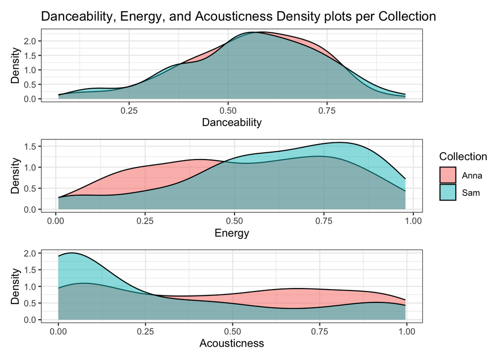

```r
# Danceability -------------
most_danceable <- combined_audio_df |>
  filter(danceability == max(danceability)) |>
  select(track.name, danceability, collection)

# view the top 3 tracks by danceability
top_danceable <- combined_audio_df |>
  arrange(desc(danceability)) |>
  select(track.name, danceability, collection) |>
  head(3)

top_dance_tracks <- top_danceable |> gt::gt() |>
  gt::opt_stylize(style = 2,
                  color = "gray")

dance_plot <- ggplot(data = combined_audio_clean) +
  geom_density(aes(x = danceability,
                  # y = tempo,
                   fill = collection),
               alpha = 0.5) +
  theme_bw() +
  # removing legend for patchwork aesthetics
  guides(fill = "none") +
  labs(x = "Danceability",
       y = "Density",
       # commenting out legend title for patchwork aesthetics
#       fill = "Collection",
       title = "Danceability, Energy, and Acousticness Density plots per Collection")


# Energy --------------

most_energy <- combined_audio_df |>
  filter(energy == max(energy)) |>
  select(track.name, energy, collection)

# most_energy

# view the top 3 tracks by energy
top_energy <- combined_audio_df |>
  arrange(desc(energy)) |>
  select(track.name, energy, collection) |>
  head(3)

top_energy_tracks <- top_energy |> gt::gt() |>
  gt::opt_stylize(style = 2,
                  color = "gray")


energy_plot <- ggplot(data = combined_audio_clean) +
  geom_density(aes(x = energy,
                  # y = tempo,
                   fill = collection),
               alpha = 0.5) +
  theme_bw() +
  labs(x = "Energy",
       y = "Density",
       fill = "Collection",
       # commenting out title for patchwork assembly aesthetics
   #    title = "Energy Density plot per Collection"
       )

# Acousticness --------------

# find most acoustic track
most_acc <- combined_audio_df |>
  filter(acousticness == max(acousticness)) |>
  select(track.name, acousticness, collection)

#most_acc

# view the top 3 tracks by acousticness
top_acoustic <- combined_audio_df |>
  arrange(desc(acousticness)) |>
  select(track.name, acousticness, collection) |>
  head(3)

top_acoustic_tracks <- top_acoustic |> gt::gt() |>
  gt::opt_stylize(style = 2,
                  color = "gray")


acc_plot <- ggplot(data = combined_audio_clean) +
  geom_density(aes(x = acousticness,
                  # y = tempo,
                   fill = collection),
               alpha = 0.5) +
  # removing legend for patchwork aesthetics
  guides(fill = "none") +
  theme_bw() +
  labs(x = "Acousticness",
       y = "Density",
       # commenting out title and legend label for patchwork aesthetics
  #     fill = "Collection",
  #     title = "Acousticness Density plot per Collection"
       )

dance_plot / energy_plot / acc_plot
```

```r
# viewing top 3 tracks by danceability, energy, and acousticness

top_dance_tracks
```

| track.name | danceability | collection |
| --- | --- | --- |
| Als ich ein Kind war | 0.948 | Sam |
| Chilling At Nemu's Place | 0.943 | Anna |
| Nails, Hair, Hips, Heels | 0.934 | Sam |

```r
top_energy_tracks
```

| track.name | energy | collection |
| --- | --- | --- |
| Panama - 2015 Remaster | 0.978 | Anna |
| Grab The Mince Pies | 0.977 | Anna |
| 冬のはなし | 0.974 | Anna |

```r
top_acoustic_tracks
```

| track.name | acousticness | collection |
| --- | --- | --- |
| Lyric Pieces, Book 1, Op. 12: Arietta | 0.996 | Anna |
| Kinderszenen, Op. 15: 7. Träumerei | 0.996 | Anna |
| Adagio and Allegro in A Flat Major, Op. 70: I. Langsam, mit innigem Ausdruck | 0.994 | Sam |

### **Modeling**

Create competing models that predict whether a track belongs to:

**Option 1. you or your partner’s collection**

Option 2. genre 1 or genre 2

You will eventually create four final candidate models:

1. k-nearest neighbor (Week 5)
2. decision tree (Week 5)
3. bagged tree (Week 6)
   - bag_tree()
   - Use the “times =” argument when setting the engine during model specification to specify the number of trees. The rule of thumb is that 50-500 trees is usually sufficient. The bottom of that range should be sufficient here.
4. random forest (Week 6)
   - rand_forest()
   - m_try() is the new hyperparameter of interest for this type of model. Make sure to include it in your tuning process

*Remember: overall goal is to build models that predict whether a given song will be in your collection vs. a partner in class.*

Go through the modeling process for each model:

Preprocessing. You can use the same recipe for all the models you create.

Resampling. Make sure to use appropriate resampling to select the best version created by each algorithm.

Tuning. Find the best values for each hyperparameter (within a reasonable range).

Compare the performance of the four final models you have created.

Use appropriate performance evaluation metric(s) for this classification task. A table would be a good way to display your comparison. Use at least one visualization illustrating your model results.

## K-Nearest Neighbors (KNN) Model

1. k-nearest neighbor (Week 5)

```r
# pseudo-random for reproducibility
set.seed(123)

# --------------- Preprocessing ---------------------
# I already classified the "collection" column to be factored earlier
# and stored this cleaned, selected df as combined_audio_clean

# split into testing and training sets
audio_split <- initial_split(combined_audio_clean, 0.75)
audio_train <- training(audio_split)
audio_test <- testing(audio_split)


# ------------ recipe, model, workflow -------------------------
knn_recipe <- recipe(collection ~ ., # outcome variable is whose collection the song is in
                  data = audio_train) |>
  step_dummy(all_nominal_predictors(), one_hot = TRUE) |>
  step_normalize(all_numeric_predictors()) |>  # scale and center numeric predictors
  prep()


knn_model <- nearest_neighbor(neighbors = tune()) |>
  # specify model again, rather than telling it we want to use 5 neighbors, telling it we're going to tune the model to get the best value of that parameter (nn)
  set_mode("classification") |>
  set_engine("kknn") # underlying function


knn_workflow <- workflow() |>  # create workflow
  add_model(knn_model) |>
  add_recipe(knn_recipe)

# --------------- Resampling ---------------------

cv_folds <- vfold_cv(audio_train, v = 10)

# --------------- Tuning ------------------------------

knn_cv_tune <- knn_workflow |>
  tune_grid(resamples = cv_folds,
            grid = data.frame(neighbors = c(1, 5, seq(10, 100, 10))))

# discussion way ----
# Fit the workflow on our predefined folds and a grid of hyperparameters
# fit_knn_cv <- knn_workflow |>
#   tune_grid(
#     cv_folds,
#     grid = data.frame(neighbors = c(1, 5, seq(10, 100, 10)))
#   )

# The final workflow for our KNN model

# knn_final_accuracy <- knn_workflow |>
#   finalize_workflow(select_best(knn_cv_tune, metric = "accuracy"))


# ---- final workflow ----
# setting final workflow, defining best NN as optimal for roc_auc
final_wf <- finalize_workflow(knn_workflow,
                               select_best(knn_cv_tune,
                                           metric = "accuracy"))

final_wf_roc_auc <- finalize_workflow(knn_workflow,
                               select_best(knn_cv_tune,
                                           metric = "roc_auc"))

# ------------- Fitting, assessing model performance ----------------

train_fit <- fit(final_wf, audio_train) # fit the KNN model to the training set
train_fit_roc <- fit(final_wf_roc_auc, audio_train) # for roc_auc metric

train_predict <- predict(object = train_fit, new_data = audio_train) |>  # predict the training set
  bind_cols(audio_train) |>   # bind training set column to prediction
  relocate(collection, .before = .pred_class) # for easier comparison
# |
#   mutate(collection = as.factor(collection))

train_predict_roc <- predict(object = train_fit_roc, new_data = audio_train) |>  # predict the training set
  bind_cols(audio_train) |>   # bind training set column to prediction
  relocate(collection, .before = .pred_class) # for easier comparison

# train_predict2 <- predict(object = train_fit, new_data = audio_train, type = "prob") %>% # predict the training set
#   bind_cols(audio_train) |>  # bind training set column to prediction
#   relocate(collection, .before = .pred_Anna)

# for accuracy
test_predict <- predict(object = train_fit,
                        new_data = audio_test) |>  # get prediction probabilities for test
  bind_cols(audio_test) |>  # bind to testing column, if you don't bind,
  mutate(collection = as.factor(collection)) |>
  relocate(collection, .before = .pred_class)

# for roc_auc
test_predict_roc <- predict(object = train_fit_roc,
                            new_data = audio_test) |>  # get prediction probabilities for test
  bind_cols(audio_test) |>  # bind to testing column, if you don't bind,
  mutate(collection = as.factor(collection)) |>
  relocate(collection, .before = .pred_class)

# test_predict2 <- predict(train_fit, audio_test, type = "prob") %>% # get testing prediction
#   bind_cols(audio_test) %>%  # bind to testing column
#   mutate(collection = as.factor(collection))




# ------------ Fitting final workflow, assessing model performance ------------
final_fit <- final_wf |>
  fit(data = audio_train)
#
# for roc_auc
final_fit_roc <- final_wf_roc_auc |>
  fit(data = audio_train)


# predicting onto testing data
audio_pred <- final_fit |>
  predict(new_data = audio_test)

# for roc_auc
audio_pred_roc <- final_fit_roc |>
  predict(new_data = audio_test)

# Write over 'final_fit' with this last_fit() approach
final_fit <- final_wf |>
  last_fit(audio_split) # takes an rsplit object

# for roc_auc
final_fit_roc <- final_wf_roc_auc |>
  last_fit(audio_split) # takes an rsplit object

# Collect metrics on the test data!
knn_metrics <- final_fit |> collect_metrics()
# knn_metrics

# for roc_auc
knn_metrics_roc <- final_fit_roc |>
  collect_metrics() |>
  mutate(model = "KNN")

# accuracy
knn_metrics <- final_fit |>
  collect_metrics() |>
  mutate(model = "KNN")
# knn_metrics_roc

# knn_metrics_roc
# knn_metrics
```

### Visualizing Model Performance

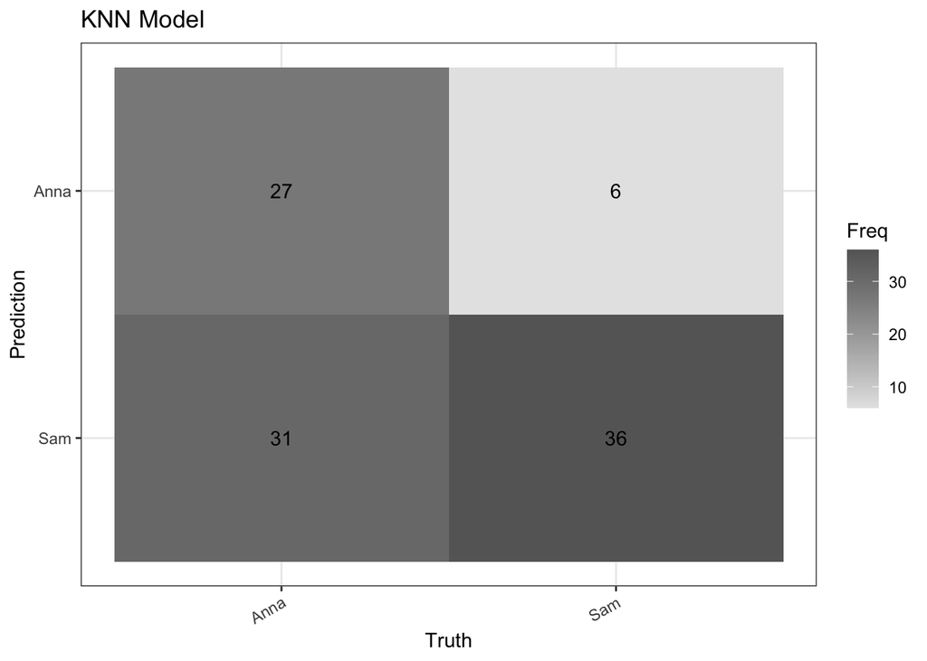

```r
# accuracy(train_predict, truth = collection, estimate = .pred_class) # get training accuracy
# accuracy(test_predict, truth = collection, estimate = .pred_class) # get testing accuracy

# sensitivity(test_predict, truth = collection, estimate = .pred_class)
# specificity(test_predict, truth = collection, estimate = .pred_class)
# sensitivity(train_predict, truth = collection, estimate = .pred_class)
# specificity(train_predict, truth = collection, estimate = .pred_class)


knn_train_conf_matrix <- train_predict |>
  conf_mat(truth = collection, estimate = .pred_class) |>  #create confusion matrix
  autoplot(type = "heatmap") + #plot confusion matrix with heatmap
  theme_bw() + #change theme
  theme(axis.text.x = element_text(angle = 30, hjust=1)) +  #rotate axis labels
  labs(title = "KNN Model: Train Prediction Confusion Matrix")

knn_conf_mat_roc <- test_predict_roc |>
  conf_mat(truth = collection, estimate = .pred_class) |>  #create confusion matrix
  autoplot(type = "heatmap") + #plot confusion matrix with heatmap
  theme_bw() + #change theme
  theme(axis.text.x = element_text(angle = 30, hjust=1)) + #rotate axis labels
  labs(title = "KNN Model")

knn_conf_mat <- test_predict |>
  conf_mat(truth = collection, estimate = .pred_class) |>  #create confusion matrix
  autoplot(type = "heatmap") + #plot confusion matrix with heatmap
  theme_bw() + #change theme
  theme(axis.text.x = element_text(angle = 30, hjust=1)) + #rotate axis labels
  labs(title = "KNN Model")

# roc_auc
#knn_conf_mat_roc
# accuracy
knn_conf_mat
```

```r
neighbors_plot <- autoplot(knn_cv_tune) + # plot cv results for parameter tuning
  theme_bw()

# neighbors_plot
```

## Decision Tree Model

2. decision tree (Week 5)

```r
set.seed(123)

# ---------- Preprocessing -------------------------
# data split ---
# audio_split <- initial_split(combined_audio_df, 0.75)
#  we did all of this earlier
# audio_train <- training(audio_split)
# audio_test <- testing(audio_split)


# ------- make recipe -----------------
tree_rec <- recipe(collection ~ . ,
                    data = audio_train) |>
  step_dummy(all_nominal_predictors(),
             one_hot = TRUE) |>
  # scale and center them --- some algorithms require scaling and centering (normalizing) -- not all, but it's a good thing to process all data like this (reducing outliers) -- random forest not required, but a "why not"
  step_normalize(all_numeric_predictors()) # or all numeric, minus all outcomes


# ---------- Resampling and Tuning ---------------


# ------- build decision tree -----------
# tuning to best option for cc, depth, min_n
tree_spec_tune <- decision_tree(
  cost_complexity = tune(),
  tree_depth = tune(),
  min_n = tune()
) |>
  set_engine("rpart") |>
  set_mode("classification")

# make grid
tree_grid <- grid_regular(dials::cost_complexity(),
                          tree_depth(),
                          min_n(),
                          levels = 5)
# tree_grid

# tune model
wf_tree_tune <- workflow() |>
  add_recipe(tree_rec) |>
  add_model(tree_spec_tune)

# Resampling ----
# set up cv fold
tree_cv <- audio_train |>
  vfold_cv(v = 10) # 10 fold cv


doParallel::registerDoParallel() #build trees in parallel

system.time(
  tree_rs <- tune_grid(
    # could also replace w workflow
    wf_tree_tune,
    resamples = tree_cv,
    grid = tree_grid, # 125 parameter combinations
    metrics = metric_set(accuracy) # tune based on accuracy
  )
)
```

```
##    user  system elapsed
##  32.371   0.687   6.843
```

```r
# tree_rs


# visualize to examine how different parameter configurations relate to accuracy

# autoplot(tree_rs) + theme_bw() + scale_colour_viridis_d()
# seems like a tree depth of 4 is typically best

# finalize workflow  -----
final_tree <- finalize_workflow(wf_tree_tune, select_best(tree_rs))
# final_tree

# ----------- Fit model, assessing model performance ---------------------

# fit finalized workflow onto training data
final_tree_fit <-  fit(final_tree, data = audio_train)

#last_fit() # fit on the training data, but then also evaluates on the test data

final_tree_result <- last_fit(final_tree, # made with finalize_workflow
                              audio_split) # fit col to predict col w the testing data

# final_tree_result$.predictions

predict_data <- as.data.frame(final_tree_result$.predictions) |>
  bind_cols(audio_test)

tree_metrics <- final_tree_result |>
  collect_metrics() |>
  mutate(model = "Decision Tree")

# get accuracy, roc_auc
# final_tree_result$.metrics

# --------- Visualization -------------------------------

# visualize most important predictors
important_preds_plot <- final_tree_fit |>
  vip(geom = "col",
      aesthetics = list(fill = "midnightblue",
                        alpha = 0.8)) +
  scale_y_continuous(expand = c(0,0)) +
  theme_bw()
# duration_ms, acousticness, instrumentalness, energy, and loudness are the top
# predictors, with duration_ms, acoustincess, and instrumentalness being of
# significantly higher importance than other predictors

duration_pred_plot <- ggplot() +
  geom_boxplot(data = predict_data, aes(x = .pred_class, duration_ms)) +
  theme_bw()

# on average, Sam listens to longer songs than Anna (me)


tree_test_predict <- predict(object = final_tree_fit,
                             new_data = audio_test) |>  # get pred probs 4 test
  bind_cols(audio_test) |>  # bind to testing column
  mutate(collection = as.factor(collection)) |>
  relocate(collection, .before = .pred_class)
```

### Visualizing Model Performance

Confusion Matrix:

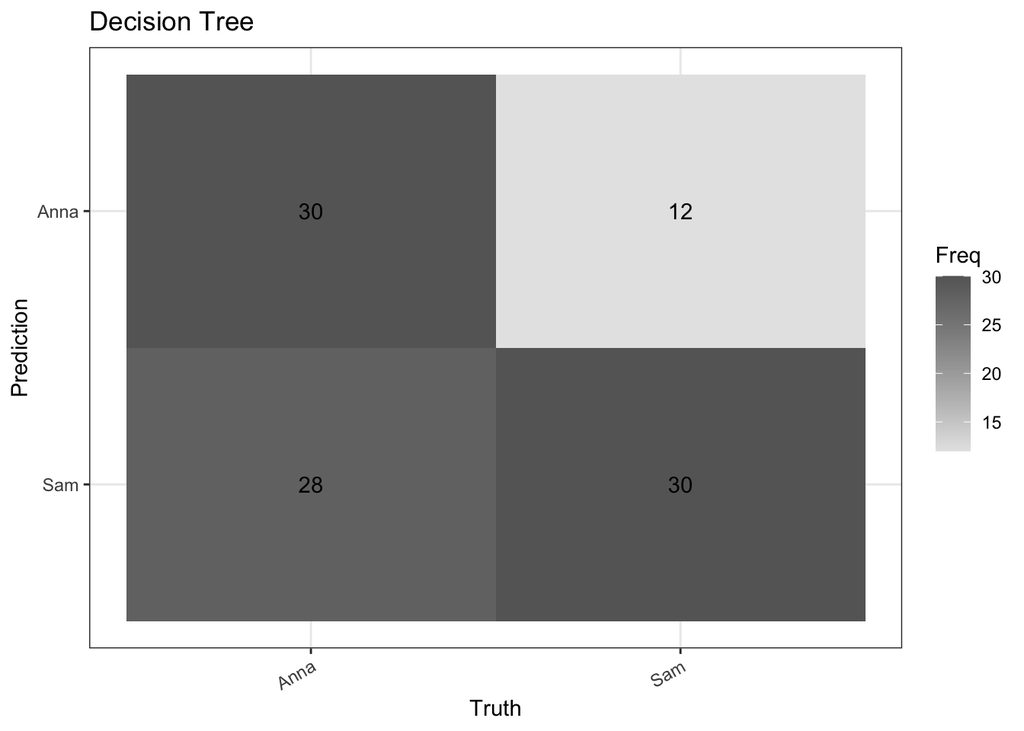

```r
# plotting confusion matrix
tree_conf_mat <- tree_test_predict |>
  conf_mat(truth = collection, estimate = .pred_class) |>
  autoplot(type = "heatmap") +
  theme_bw() +
  theme(axis.text.x = element_text(angle = 30, hjust = 1)) +
  labs(title = "Decision Tree")

tree_conf_mat
```

## Bagged Tree Model

3. bagged tree (Week 6)
   - bag_tree()
   - Use the “times =” argument when setting the engine during model specification to specify the number of trees. The rule of thumb is that 50-500 trees is usually sufficient. The bottom of that range should be sufficient here.

```r
set.seed(123) # pseudo-random for reproducibility

# ------------ Preprocessing -------------
# ?details_bag_tree_rpart

# split into testing and training sets (did this earlier)
# audio_split <- initial_split(combined_audio_clean, 0.75)
# audio_train <- training(audio_split)
# audio_test <- testing(audio_split)


# ------------ recipe, model, workflow -------------------------
# recipe
bag_recipe <- recipe(collection ~ ., # outcome variable is whose collection the song is in
                  data = audio_train) |>
  step_dummy(all_nominal_predictors(), one_hot = TRUE) |>
  step_normalize(all_numeric_predictors())   # scale and center numeric predictors
#   prep()

# model
bag_model <- bag_tree(
  cost_complexity = tune(),
  min_n = tune()) |>
  set_engine("rpart",
             times = 50) |> # 50 times
  set_mode("classification")

# workflow
bag_wf_tune <- workflow() |>
  add_model(bag_model) |>
  add_recipe(bag_recipe)

# --------------- Resampling ---------------------
# specifying grid
bag_grid <- grid_regular(dials::cost_complexity(),
                          min_n(),
                          levels = 5)


# same cv fold from earlier
# tree_cv <- audio_train |>
#   vfold_cv(v = 10) # 10 fold cv

# --------------- Tuning ------------------------------

doParallel::registerDoParallel() #build trees in parallel

system.time(
  bag_rs <- tune_grid(
    bag_wf_tune, # bag tree workflow here
    resamples = tree_cv,
    grid = bag_grid, # 125 parameter combinations
    metrics = metric_set(accuracy) # tune based on accuracy
  )
)
```

```
##    user  system elapsed
## 108.391   0.985  22.176
```

```r
# bag_rs

# finalize workflow  -----
final_bag <- finalize_workflow(bag_wf_tune, select_best(bag_rs))

# -------- Fitting -------------
# fit finalized workflow onto training data
final_bag_fit <-  fit(final_bag, data = audio_train)

#last_fit() # fit on the training data, but then also evaluates on the test data

final_bag_result <- last_fit(final_bag, # made with finalize_workflow
                             # fit col to predict col w the testing data
                              audio_split)

# final_tree_result$.predictions

predict_data_bag <- as.data.frame(final_bag_result$.predictions) |>
  bind_cols(audio_test)

bag_metrics <- final_bag_result |>
  collect_metrics() |>
  mutate(model = "Bagged Tree")
# bag_metrics

# bag_train_predict <- predict(object = final_bag_fit,
#                              new_data = audio_train) |> # get pred probs 4 test
#   bind_cols(audio_test) |>  # bind to testing column
#   mutate(collection = as.factor(collection)) |>
#   relocate(collection, .before = .pred_class)

bag_test_predict <- predict(object = final_bag_fit,
                             new_data = audio_test) |>  # get pred probs 4 test
  bind_cols(audio_test) |>  # bind to testing column
  mutate(collection = as.factor(collection)) |>
  relocate(collection, .before = .pred_class)
```

### Visualizing Model Performance

Confusion Matrix:

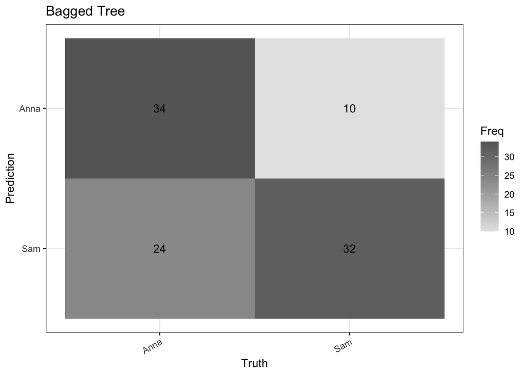

```r
# ---------- Visualizing model performance ----------------------

bag_conf_mat <- bag_test_predict |>
  conf_mat(truth = collection, estimate = .pred_class) |>
  autoplot(type = "heatmap") +
  theme_bw() +
  theme(axis.text.x = element_text(angle = 30, hjust = 1)) +
  labs(title = "Bagged Tree")

bag_conf_mat
```

## Random Forest Model

4. random forest (Week 6)
   - rand_forest()
   - m_try() is the new hyperparameter of interest for this type of model. Make sure to include it in your tuning process Random forest: random number/subset of features used at every split and the best split feature from that random selection is used

```r
# pseudo-random for reproducibility
set.seed(123)

# ?ranger
# ------------ Preprocessing -------------

# already split into test and train datasets

# using the same decision tree recipe
# tree_recipe <- recipe(collection ~ .,
#                     # outcome variable is whose collection the song is in
#                   data = audio_train) |>
#   step_dummy(all_nominal_predictors(), one_hot = TRUE) |>
#   step_normalize(all_numeric_predictors())   # scale and center numeric predictors

# define model
rf_model <- rand_forest(
  mtry = tune(),
  trees = tune()
) |>
  set_engine("ranger") |>
  set_mode("classification") # can do reg or class

# create workflow
rf_workflow <- workflow() |>
  add_model(rf_model) |>
  add_recipe(recipe = tree_rec)

# --------------- Resampling ---------------------

# same cv fold from earlier
# tree_cv <- audio_train |>
#   vfold_cv(v = 10) # 10 fold cv

# --------------- Tuning ------------------------------
rf_cv_tune <- rf_workflow |>
  tune_grid(resamples = tree_cv,
            grid = 10) # use cross validation to tune mtry and trees parameters

# specifying grid
# rf_grid <- grid_regular(dials::mtry(), # yields error, says mtry contains unknowns
#                           trees(),
#                           levels = 5)

#
# doParallel::registerDoParallel() #build trees in parallel
#
# system.time(
#   rf_rs <- tune_grid(
#     rf_workflow_tune, # random forest workflow here
#     resamples = tree_cv,
#     grid = rf_grid, # 125 parameter combinations
#     metrics = metric_set(accuracy) # tune based on accuracy
#   )
# )

# autoplot(rf_cv_tune)

# viewing best options based on accuracy and roc_auc
rf_best_acc <- show_best(rf_cv_tune, n = 1, metric = "accuracy")
rf_best_roc_auc <- show_best(rf_cv_tune, n = 1, metric = "roc_auc")
# rf_best_acc
# rf_best_roc_auc

#  ------- finalize workflow ---------
rf_final_roc_auc <- finalize_workflow(rf_workflow,
                              select_best(rf_cv_tune, metric = "roc_auc"))

rf_final_accuracy <- finalize_workflow(rf_workflow,
                              select_best(rf_cv_tune, metric = "accuracy"))

# --------- Fitting, assessing model performance ------------------
#fit the RF model to the training set for roc_auc and accuracy-optimized models
train_fit_rf <- fit(rf_final_roc_auc, audio_train)

train_fit_rf_acc <- fit(rf_final_accuracy, audio_train)

# last fit from final wf
# Write over 'final_fit' with this last_fit() approach
rf_final_fit <- rf_final_roc_auc |>
  last_fit(audio_split) # takes an rsplit object


# get test predictions
test_predict_rf_roc_auc <- predict(train_fit_rf, audio_test) |>  # get prediction probabilities for test
  # gets predicted class .pred_class (same type as your truth class)
  bind_cols(audio_test) |>   #bind to testing column
  mutate(collection = as.factor(collection)) |>
  relocate(collection, .before = .pred_class)

test_predict_rf_acc <- predict(train_fit_rf_acc, audio_test) |>  # get prediction probabilities for test
  # gets predicted class .pred_class (same type as your truth class)
  bind_cols(audio_test) |>   #bind to testing column
  mutate(collection = as.factor(collection)) |>
  relocate(collection, .before = .pred_class)


# get probability, not class
test_predict2_rf <- predict(train_fit_rf, audio_test, type = "prob") |>  # get testing prediction
  bind_cols(audio_test) |>  #bind to testing column
  mutate(collection = as.factor(collection)) |>
  relocate(collection, .before = .pred_Anna)

# get accuracy of testing prediction
# (commented out because I'll compare them all at the end)
# accuracy(test_predict_rf_roc_auc, truth = collection, estimate = .pred_class)
# accuracy(test_predict_rf_acc, truth = collection, estimate = .pred_class)

# test_roc_auc_rf <- roc_curve(data = test_predict2_rf, truth = collection, .pred_Anna, .pred_Sam)

# collect metrics ------

rf_metrics <- rf_final_fit |> collect_metrics() |>
  mutate(model = "Random Forest")

# rf_metrics
```

### Visualizing Model Performance

Confusion Matrix:

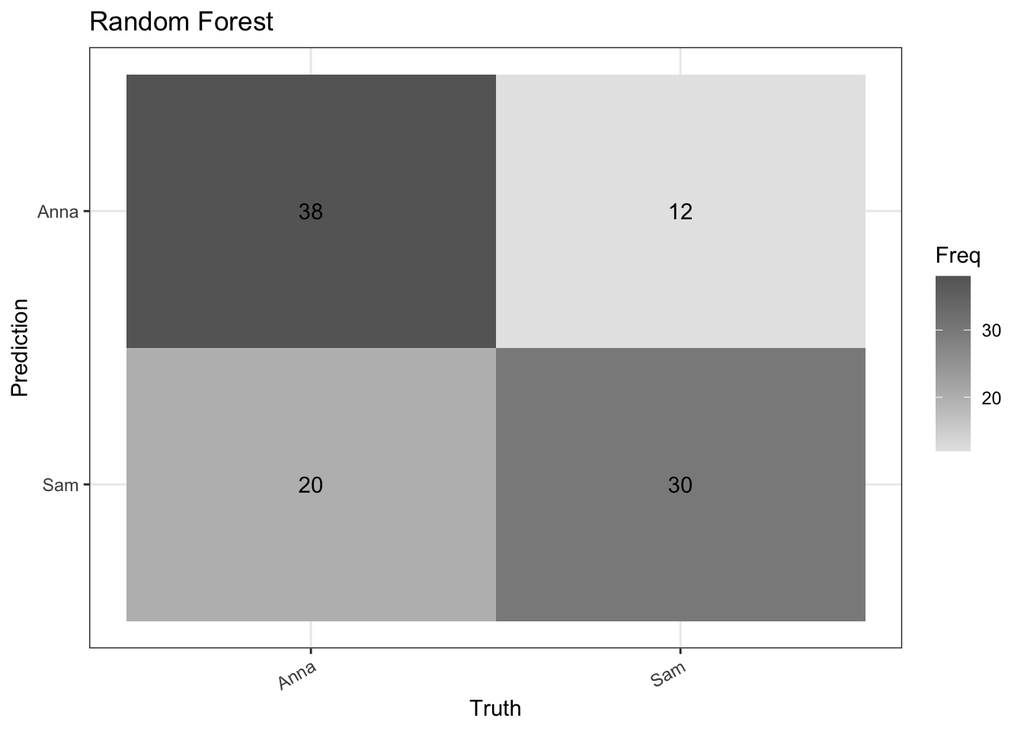

```r
rf_conf_mat <- test_predict_rf_roc_auc |>
  conf_mat(truth = collection, estimate = .pred_class) |>  #create confusion matrix
  autoplot(type = "heatmap") + #plot confusion matrix with heatmap
  theme_bw() + #change theme
#  scale_fill_manual(breaks = c(0, 10, 20, 30, 40)) +
  theme(axis.text.x = element_text(angle = 30, hjust=1)) +
  #rotate axis labels
  labs(title = "Random Forest")
rf_conf_mat
```

```r
rf_conf_mat_acc <- test_predict_rf_acc |>
  conf_mat(truth = collection, estimate = .pred_class) |>  #create confusion matrix
  autoplot(type = "heatmap") + #plot confusion matrix with heatmap
  theme_bw() + #change theme
  theme(axis.text.x = element_text(angle = 30, hjust=1)) +
  #rotate axis labels
  labs(title = "Random Forest: Test Prediction Confusion Matrix")
# rf_conf_mat_acc
```

Compare model performance:

“Use appropriate performance evaluation metric(s) for this classification task. A table would be a good way to display your comparison. Use at least one visualization illustrating your model results.”

```r
# make a final table to compare performance
# based on last_fit() |> collect_metrics()
performance_metrics <- rbind(knn_metrics,
                             tree_metrics,
                             bag_metrics,
                             rf_metrics
                             ) |>
  relocate(model, .before = .metric) |>
  select(-.config, -.estimator) |>
  rename(estimate = .estimate,
         metric = .metric)

#performance_metrics |> knitr::kable()
performance_table <- performance_metrics |> gt::gt(
  rowname_col = "metric",
  groupname_col = "model",
  row_group_as_column = TRUE
) |>
  gt::fmt_number(
    columns = "estimate",
    decimals = 4
  ) |>
  gt::opt_stylize(style = 2,
                  color = "gray")
performance_table
```

|  |  | estimate |
| --- | --- | --- |
| KNN | accuracy | 0.6300 |
|  | roc_auc | 0.7440 |
| Decision Tree | accuracy | 0.6000 |
|  | roc_auc | 0.6340 |
| Bagged Tree | accuracy | 0.6800 |
|  | roc_auc | 0.7301 |
| Random Forest | accuracy | 0.6800 |
|  | roc_auc | 0.7342 |

This table shows us that the best performing models for our data are the Random Forest and Bagged Tree model (roc_auc slightly higher for Random Forest than Bagged Trees), with roc_auc and accuracy scoring slightly higher than all other models, other than KNN, which has a higher roc_auc score. Based on the confusion matrices, the Random Forest model seems to perform the best on our data, with the fewest false negatives and false postives compared to true positives and true negatives.

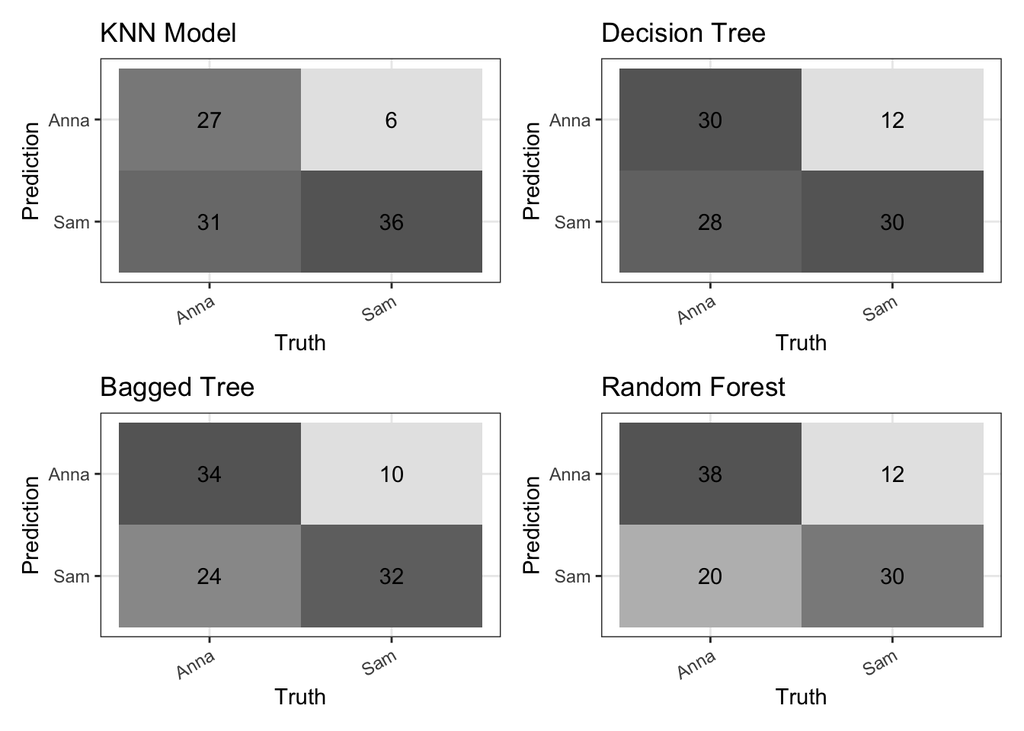

```r
# using patchwork to display all confusion matrices
((knn_conf_mat + theme(legend.position = "none")) +
   (tree_conf_mat + theme(legend.position = "none"))) /
  ((bag_conf_mat  + theme(legend.position = "none")) +
    (rf_conf_mat + theme(legend.position = "none")))
```

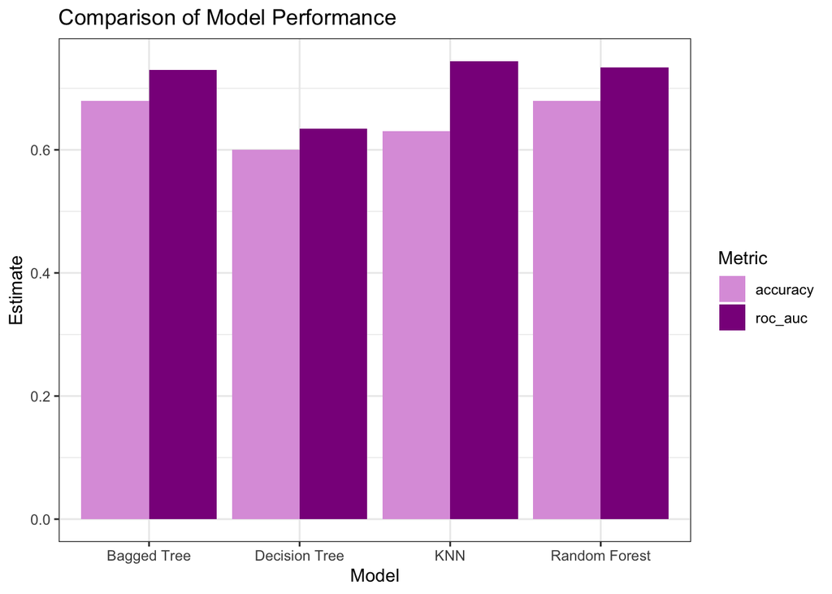

```r
# bar plot of model performance metrics
comparison_bar_plot <- ggplot(data = performance_metrics) +
  geom_bar(aes(x = model,
               y = estimate,
               fill = metric),
           stat = "identity", position = "dodge") +
  scale_fill_manual(values = c("plum", "darkmagenta")) +
  theme_bw() +
  labs(x = "Model",
       y = "Estimate",
       fill = "Metric",
       title = "Comparison of Model Performance")

comparison_bar_plot
```